# Reproducible Analytical Pipelines

December 4, 2018  
Slides: https://github.com/NHS-NSS-transforming-publications/RAP-presentation  
RAP companion: https://ukgovdatascience.github.io/rap_companion/

## Reproducible research

- Not a new concept
- Encouraged and growing within academia for last 10-15 years
- Provides evidence of the correctness of results
- Exposes workflow to others
- Enables others to make use of methods and results

[figure not shown]

## Current publication process

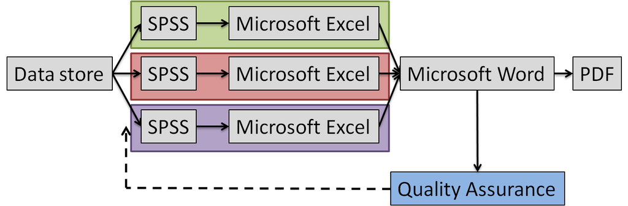

- Complex (many steps between software)
- Prone to error
- Manual, menial tasks carried out by highly skilled people
- Not reproducible or sustainable

[figure not shown]

## The solution

[figure not shown]

[RAP companion](https://ukgovdatascience.github.io/rap_companion/)

Combined the priniciples of **reproducible research** with **data science tools and best practice**.

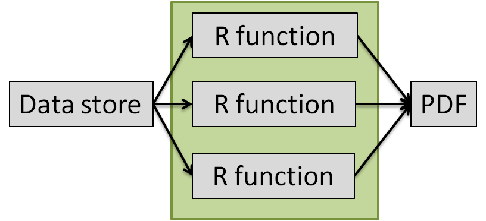

## Why R?

[figure not shown]

## Transforming Publishing test case: Hospital Standardised Mortality Ratio publication

[figure not shown]

## Levels of automation

| Level | Description |
| --- | --- |
| 1 | Ad hoc R code |
| 2 | R project |
| 3 | R project under version control (VC) |
| 4a | R project under VC and peer reviewed (wrangling) |
| 4b | Replicable report in Rmarkdown (publication) |
| 5 | Near RAP (VC, peer review, data quality assurance) |
| 6 | Full RAP (as above plus unit testing and documentation) |
| 7 | R package |

## Challenges

- Culture change (peer review and working in the open)
- New software such as R and git
- Required development time
- Range of data sources and/or unstable production process
- IT (R server and internally hosted code repository)

## Interested in RAP?…

- How many reports do your team produce?
- What proportion of time is spent producing reports?
- How much copying and pasting/data movement between software is involved?
- What proportion of your spreadsheet or report contains errors?
- What would the impact of mistakes in production be?
- Could your team create the report if certain team members suddenly left?
- Could you reproduce your publication statistics from 5 years ago?

Contact the Transforming Publishing team (nss.isdtransformingpublishing@nhs.net)

## Thank You

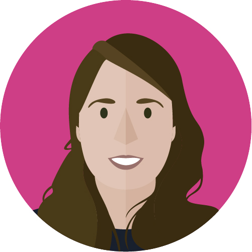

[figure not shown]

@price_AH

[figure not shown]

annahprice

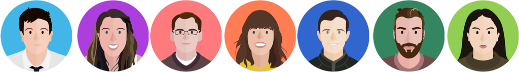

Contact Transforming Publishing: nss.isdtransformingpublishing@nhs.net

Transforming Publishing on GitHub:  
https://github.com/NHS-NSS-transforming-publications

ISD on GitHub: https://github.com/Health-SocialCare-Scotland

RAP companion: https://bit.ly/2PhLYbL